# SISCER_Survival_Day1

Pamela Shaw

2026-07-08

## Kaplan-Meier Survival Curves Example 1

The code below introduces the Kaplan-Meier estimator using a toy dataset with no censoring. It shows how to fit a basic survival curve and summarize survival probabilities over time using `survfit()`.

```r
# Create a simple hypothetical dataset with 10 subjects, no censoring
status <- rep(1, 10)
time <- c(4, 5, 6, 8, 8, 8, 10, 10, 11, 12)
leedata <- data.frame(status, time)

# Fit a Kaplan-Meier survival curve for a single (unstratified) group
lee.surv <- survfit(Surv(time, status) ~ 1, data = leedata)

# Summarize survival probabilities at each observed event time
summary(lee.surv)
```

```
## Call: survfit(formula = Surv(time, status) ~ 1, data = leedata)
##
##  time n.risk n.event survival std.err lower 95% CI upper 95% CI
##     4     10       1      0.9  0.0949       0.7320        1.000
##     5      9       1      0.8  0.1265       0.5868        1.000
##     6      8       1      0.7  0.1449       0.4665        1.000
##     8      7       3      0.4  0.1549       0.1872        0.855
##    10      4       2      0.2  0.1265       0.0579        0.691
##    11      2       1      0.1  0.0949       0.0156        0.642
##    12      1       1      0.0     NaN           NA           NA
```

## Plot the K-M curves

The code below plots the Kaplan-Meier survival curve from the previous example using base R graphics.

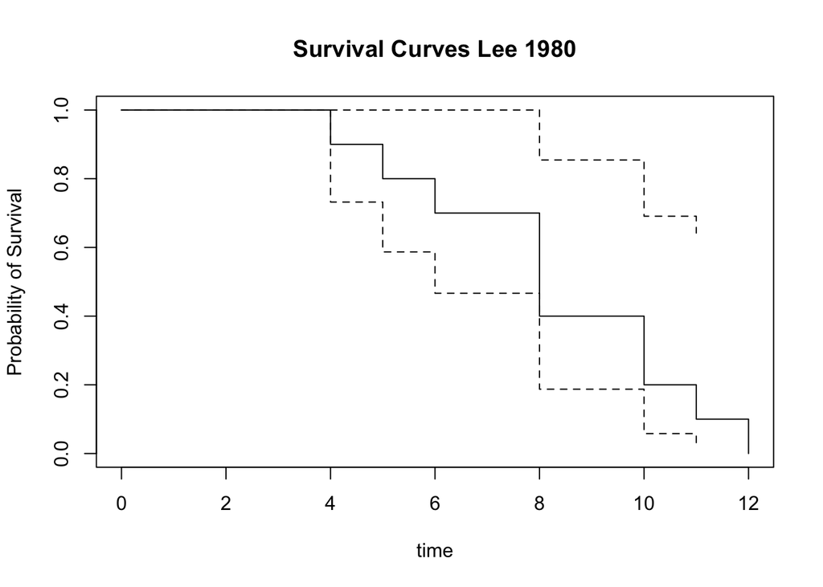

```r
# Plot the Kaplan-Meier survival curve with labeled axes
plot(lee.surv, ylab = "Probability of Survival", xlab = "time")
title("Survival Curves Lee 1980")
```

## Comparison of pointwise 95% CI

The code below compares different methods for calculating confidence intervals on KM curves. It contrasts the default (log) intervals with log(-log) transformed intervals.

```r
# Refit the Kaplan-Meier model using log(-log) transformation for CIs
lee.surv2 <- survfit(Surv(time, status) ~ 1, data = leedata, conf.type = "log-log")
summary(lee.surv2)
```

```
## Call: survfit(formula = Surv(time, status) ~ 1, data = leedata, conf.type = "log-log")
##
##  time n.risk n.event survival std.err lower 95% CI upper 95% CI
##     4     10       1      0.9  0.0949      0.47301        0.985
##     5      9       1      0.8  0.1265      0.40869        0.946
##     6      8       1      0.7  0.1449      0.32872        0.892
##     8      7       3      0.4  0.1549      0.12269        0.670
##    10      4       2      0.2  0.1265      0.03091        0.475
##    11      2       1      0.1  0.0949      0.00572        0.358
##    12      1       1      0.0     NaN           NA           NA
```

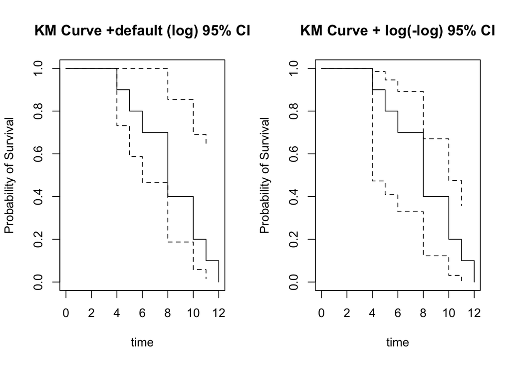

```r
# Plotting code
par(mfrow = c(1, 2))

# Plot the original KM curve with default (log) confidence intervals
plot(lee.surv, ylab = "Probability of Survival", xlab = "time")
title("KM Curve +default (log) 95% CI")

# Plot the KM curve with log(-log) confidence intervals
plot(lee.surv2, ylab = "Probability of Survival", xlab = "time")
title("KM Curve + log(-log) 95% CI")
```

## Example 2: K-M curve with censoring

The code below introduces right-censoring by including both events and censored observations. It fits Kaplan-Meier survival curves and compares default versus log(-log) confidence intervals.

```r
# Create a dataset with 10 subjects, including both events (1) and censored
# observations (0)
status <- c(1, 1, 0, 1, 0, 1, 0, 1, 1, 0)
time <- c(1, 2, 4, 5, 6, 8, 8, 10, 10, 12)
ex2data <- data.frame(status, time)

# Fit Kaplan-Meier survival curve with default confidence intervals
ex2.surv <- survfit(Surv(time, status) ~ 1, data = ex2data)
summary(ex2.surv)
```

```
## Call: survfit(formula = Surv(time, status) ~ 1, data = ex2data)
##
##  time n.risk n.event survival std.err lower 95% CI upper 95% CI
##     1     10       1    0.900  0.0949       0.7320            1
##     2      9       1    0.800  0.1265       0.5868            1
##     5      7       1    0.686  0.1515       0.4447            1
##     8      5       1    0.549  0.1724       0.2963            1
##    10      3       2    0.183  0.1600       0.0329            1
```

```r
# Fit again using log(-log) transformed confidence intervals
ex2.surv2 <- survfit(Surv(time, status) ~ 1, data = ex2data, conf.type = "log-log")
summary(ex2.surv2)
```

```
## Call: survfit(formula = Surv(time, status) ~ 1, data = ex2data, conf.type = "log-log")
##
##  time n.risk n.event survival std.err lower 95% CI upper 95% CI
##     1     10       1    0.900  0.0949      0.47301        0.985
##     2      9       1    0.800  0.1265      0.40869        0.946
##     5      7       1    0.686  0.1515      0.30459        0.887
##     8      5       1    0.549  0.1724      0.18726        0.806
##    10      3       2    0.183  0.1600      0.00945        0.538
```

## Example 2 KM Curve + pointwise 95% CI

The code below plots the Kaplan-Meier survival curve for the censored dataset introduced earlier. It includes pointwise 95% confidence intervals and marks the censored observations with tick marks.

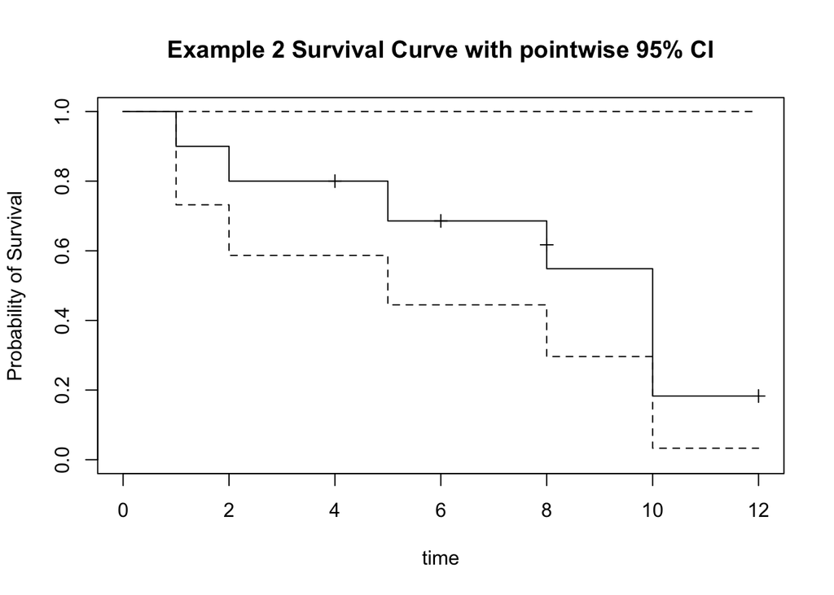

```r
# Plot Kaplan-Meier survival curve with pointwise 95% confidence intervals
# 'mark.time=TRUE' adds tick marks at censored observations
plot(ex2.surv, ylab = "Probability of Survival", xlab = "time", mark.time = TRUE)
title("Example 2 Survival Curve with pointwise 95% CI")
```

## Example 2 KM Curve pointwise 95% CI comparison

The code below visually compares two approaches for displaying 95% confidence intervals on KM curves: the default (log) method and the log(-log) transformation.

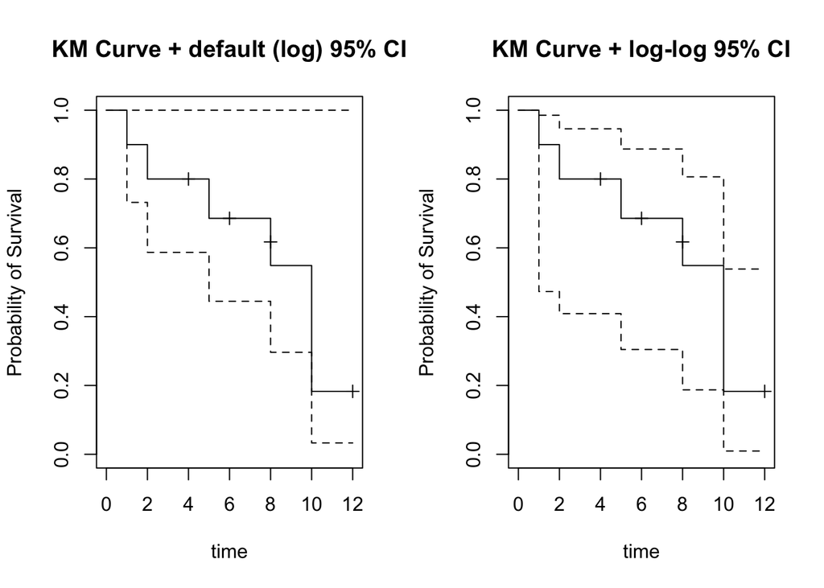

```r
par(mfrow = c(1, 2))

# Plot KM curve with default (log) confidence intervals
plot(ex2.surv, ylab = "Probability of Survival", xlab = "time", mark.time = TRUE)
title("KM Curve + default (log) 95% CI")

# Plot KM curve with log(-log) confidence intervals
plot(ex2.surv2, ylab = "Probability of Survival", xlab = "time", mark.time = TRUE)
title("KM Curve + log-log 95% CI")
```

## Example KM curve + simultaneous confidence bands

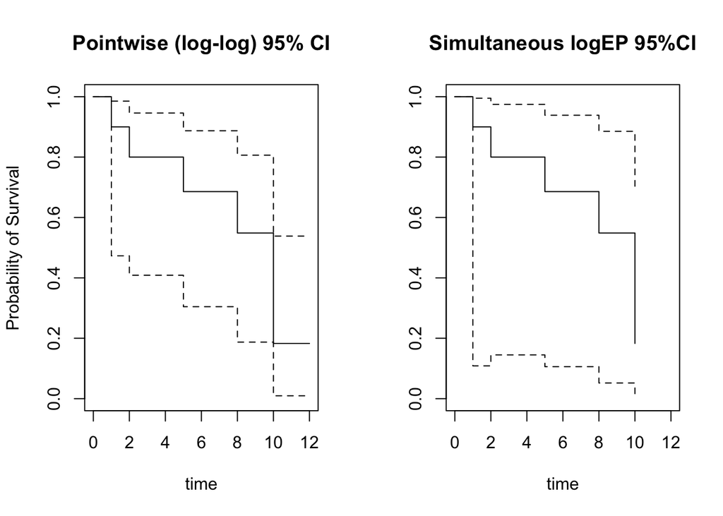

```r
par(mfrow = c(1, 2))

# Plot KM curve with pointwise arcsine-transformed 95% confidence intervals
plot(ex2.surv2, ylab = "Probability of Survival", xlab = "time", xlim = c(0, 12))
title("Pointwise (log-log) 95% CI")

# Use km.ci() from the 'km.ci' package to compute simultaneous confidence
# intervals (logEP method)
fit.simul <- km.ci(ex2.surv, method = "logep")
plot(fit.simul, xlim = c(0, 12), xlab = "time")
title("Simultaneous logEP 95%CI")
```

## AML Example: K-M curves by intervention arm

The code below uses the `aml` dataset to compare survival curves between two treatment arms. Kaplan-Meier curves are plotted with confidence intervals and a legend, allowing for visual assessment of treatment effects on survival.

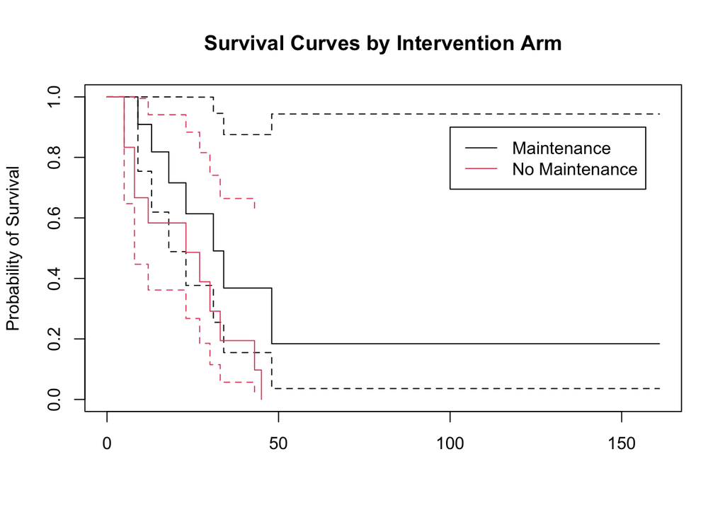

```r
# Load the built-in 'aml' dataset from the survival package
data(cancer, package = "survival")

# Fit Kaplan-Meier survival curves stratified by treatment group ('x')
leukemia.surv <- survfit(Surv(time, status) ~ x, data = aml)

# Plot survival curves for each treatment arm with confidence intervals
plot(leukemia.surv, ylab = "Probability of Survival", conf.int = TRUE, col = 1:2)
legend(100, 0.9, c("Maintenance", "No Maintenance"), col = 1:2, lty = 1)
title("Survival Curves by Intervention Arm")
```

## A more informative plot using ggsurvplot

The code below uses the `ggsurvfit` package to create an enhanced Kaplan-Meier plot by treatment arm. It adds a risk table, custom colors, and improved visual formatting using `ggplot2`-style theming for clearer presentation.

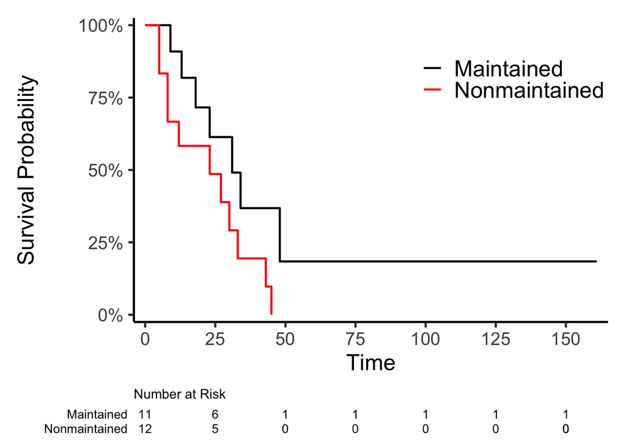

```r
# Load the ggsurvfit package for ggplot-based survival curves
library(ggsurvfit)

# Fit survival curves by treatment arm and create a ggplot-based Kaplan-Meier plot
survfit2(Surv(time, status) ~ x, data = aml) %>%
  ggsurvfit(linewidth = 0.8) +
  add_risktable(risktable_stats = "n.risk",
                stats_label = list(n.risk = "Number at Risk")) +
  scale_ggsurvfit() +
  scale_color_manual(values = c('black', 'red')) +
  scale_fill_manual(values = c('black', 'red')) +
  theme_classic(base_size = 18) +
  theme(
    legend.text = element_text(size = rel(1)),
    legend.position = "inside",
    legend.position.inside = c(0.8, 0.8)
  )
```

## More fine-tuning formats using ggsurvplot

The code below demonstrates additional customization of Kaplan-Meier plots using `ggsurvfit`.

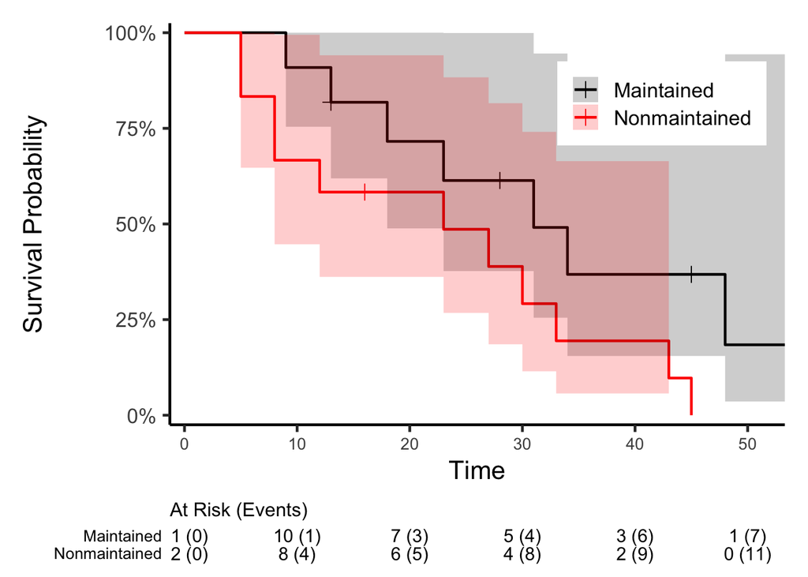

```r
# Create a customized Kaplan-Meier plot using ggsurvfit
survfit2(Surv(time, status) ~ x, data = aml) %>%
  ggsurvfit(linewidth = 0.8) +
  add_censor_mark(size = 3) +
  coord_cartesian(xlim = c(0, 52)) +
  add_risktable(
    size = 4,
    theme = theme_risktable_default(axis.text.y.size = 10, plot.title.size = 12),
    risktable_stats = "{n.risk} ({cum.event})"
  ) +
  scale_ggsurvfit() +
  scale_color_manual(values = c('black', 'red')) +
  scale_fill_manual(values = c('black', 'red')) +
  theme_classic(base_size = 18) +
  theme(
    axis.text.x = element_text(size = rel(0.8)),
    text = element_text(size = 16),
    legend.text = element_text(size = rel(0.8)),
    legend.position = "inside",
    legend.position.inside = c(0.8, 0.8)
  ) +
  add_confidence_interval()
```

## Another example of shaded confidence intervals

The code below shows how to generate a Kaplan-Meier plot using the `lung` dataset, with shaded confidence intervals and a number-at-risk table.

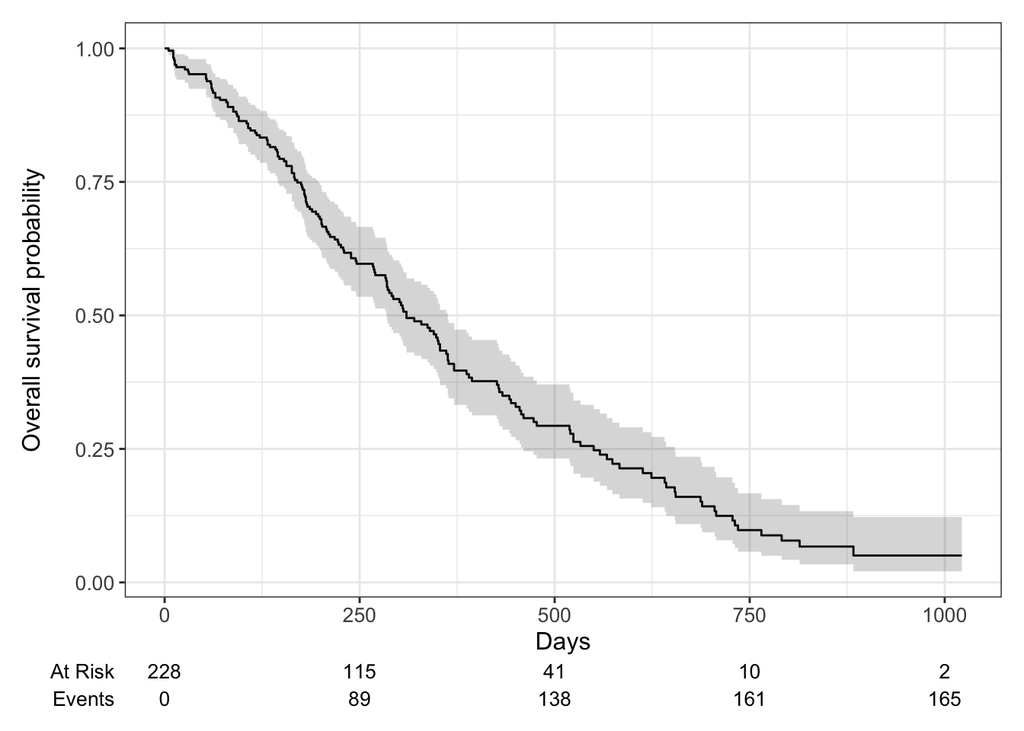

```r
# Plot an overall Kaplan-Meier curve using the 'lung' dataset,
# including shaded confidence intervals and a number-at-risk table
survfit2(Surv(time, status) ~ 1, data = lung) %>%
  ggsurvfit() +
  labs(
    x = "Days",
    y = "Overall survival probability"
  ) +
  add_confidence_interval() +
  add_risktable()
```

## A Lifetable example

The code below introduces life table analysis using grouped time intervals. It uses the `lifetab()` function from the `KMsurv` package to calculate survival estimates based on interval-level data, including number at risk, events, and censoring per interval.

```r
# Load the KMsurv package, which contains the lifetab() function
library(KMsurv)

# Define the beginning of each time interval (increasing order)
k <- c(0, 3, 5, 7, 10, 12, 16, 19, 28, 31)

# Number at risk at the start of each interval
nk <- c(569, 278, 180, 107, 55, 39, 18, 12, 5)

# Number of events (e.g., deaths) in each interval
dk <- c(121, 33, 24, 22, 2, 10, 1, 5, 1)

# Number of censored/lost subjects in each interval
ck <- c(170, 65, 49, 30, 14, 11, 5, 2, 1)

options(width = 120)

# Create and display the life table based on interval data
lifetab(tis = k, ninit = nk[1], nlost = ck, nevent = dk)
```

```
##       nsubs nlost nrisk nevent      surv         pdf     hazard    se.surv      se.pdf   se.hazard
## 0-3     569   170 484.0    121 1.0000000 0.083333333 0.09523810 0.00000000 0.006560799 0.008569206
## 3-5     278    65 245.5     33 0.7500000 0.050407332 0.07205240 0.01968240 0.008270247 0.012510113
## 5-7     180    49 155.5     24 0.6491853 0.050097904 0.08362369 0.02359740 0.009578670 0.017009827
## 7-10    107    30  92.0     22 0.5489895 0.043760035 0.09053498 0.02742181 0.008426499 0.019123306
## 10-12    55    14  48.0      2 0.4177094 0.008702280 0.02127660 0.03211507 0.006060922 0.015041419
## 12-16    39    11  33.5     10 0.4003049 0.029873497 0.08771930 0.03305100 0.008287737 0.027309052
## 16-19    18     5  15.5      1 0.2808109 0.006038944 0.02222222 0.03923256 0.005901513 0.022209873
## 19-28    12     2  11.0      5 0.2626940 0.013267376 0.06535948 0.04066988 0.004839586 0.027936797
## 28-31     5     1   4.5      1 0.1432877          NA         NA 0.04524949          NA          NA
```

## `lung` data description

The code below loads and explores the `lung` dataset from the `survival` package. It fits an overall Kaplan-Meier survival curve using log(-log) confidence intervals, prints out the survfit object (which has the median survival estimate and confidence interval), and uses the summary command to examine the survival estimates at event times.

```r
# Load the lung cancer dataset from the survival package
data(cancer, package = "survival")

# Display the first few rows to examine the structure of the dataset
head(lung)
```

```
##   inst time status age sex ph.ecog ph.karno pat.karno meal.cal wt.loss
## 1    3  306      2  74   1       1       90       100     1175      NA
## 2    3  455      2  68   1       0       90        90     1225      15
## 3    3 1010      1  56   1       0       90        90       NA      15
## 4    5  210      2  57   1       1       90        60     1150      11
## 5    1  883      2  60   1       0      100        90       NA       0
## 6   12 1022      1  74   1       1       50        80      513       0
```

```r
# Fit an overall Kaplan-Meier survival curve using the lung dataset
# Using log(-log) transformation for confidence intervals
lung.surv <- survfit(Surv(time, status) ~ 1, data = lung, conf.type = "log-log")

# Print the fitted survfit object and display the summary estimates
lung.surv
```

```
## Call: survfit(formula = Surv(time, status) ~ 1, data = lung, conf.type = "log-log")
##
##        n events median 0.95LCL 0.95UCL
## [1,] 228    165    310     284     361
```

```r
summary(lung.surv)
```

```
## Call: survfit(formula = Surv(time, status) ~ 1, data = lung, conf.type = "log-log")
##
##  time n.risk n.event survival std.err lower 95% CI upper 95% CI
##     5    228       1   0.9956 0.00438       0.9693        0.999
##    11    227       3   0.9825 0.00869       0.9539        0.993
##    12    224       1   0.9781 0.00970       0.9481        0.991
##    13    223       2   0.9693 0.01142       0.9367        0.985
##    15    221       1   0.9649 0.01219       0.9311        0.982
##    26    220       1   0.9605 0.01290       0.9255        0.979
##    30    219       1   0.9561 0.01356       0.9200        0.976
##    31    218       1   0.9518 0.01419       0.9146        0.973
##    53    217       2   0.9430 0.01536       0.9038        0.966
##    54    215       1   0.9386 0.01590       0.8985        0.963
##    59    214       1   0.9342 0.01642       0.8932        0.960
##    60    213       2   0.9254 0.01740       0.8828        0.953
```

[output cut: 127 more lines]

## Median survival

The code below calculates and displays the median survival time from a Kaplan-Meier model into a formatted table using the `tbl_survfit()` function from the `gtsummary` package.

```r
# Load gtsummary package for producing publication-style summary tables
library(gtsummary)

# Fit Kaplan-Meier curve (no covariates, i.e. overall survival)
# Use log-log confidence intervals, then format the output as a table
survfit(Surv(time, status) ~ 1, data = lung, conf.type = "log-log") %>%
  tbl_survfit(
    probs = 0.5,  # Show the median survival time
    label_header = "**Median survival (95% CI)**"
  )
```

| **Characteristic** | **Median survival (95% CI)** |
| --- | --- |
| Overall | 310 (284, 361) |

## Survfit provides summaries at specified times

The code below demonstrates how to extract survival probabilities at specific time points (e.g., 6, 12, 24, 60 months) using the `summary()` function on a Kaplan-Meier model. Time is first converted from days to months for clarity.

```r
# Convert survival time from days to months
lung$months <- lung$time / (365.25 / 12)

# Fit Kaplan-Meier curve and report survival probabilities at 6, 12, 24, and 60 months
summary(
  survfit(Surv(months, status) ~ 1, data = lung, conf.type = "log-log"),
  times = c(6, 12, 24, 60)
)
```

```
## Call: survfit(formula = Surv(months, status) ~ 1, data = lung, conf.type = "log-log")
##
##  time n.risk n.event survival std.err lower 95% CI upper 95% CI
##     6    156      66    0.708  0.0303       0.6440        0.763
##    12     65      55    0.409  0.0358       0.3387        0.478
##    24     13      38    0.116  0.0283       0.0676        0.178
```

## Table of survival at a given time point

The code below summarizes survival probabilities at selected time points (6, 12, 24, 60 months) stratified by sex. It relabels the sex variable for clarity and uses `tbl_survfit()` to generate a well-formatted summary table with custom column headers.

```r
# Convert survival time from days to months
lung$months <- lung$time / (365.25 / 12)

# Relabel the sex variable to show "male" and "female" instead of numeric codes
lung$sex <- factor(lung$sex, labels = c("male", "female"))

# Fit Kaplan-Meier curves by sex, and summarize survival at specific months
survfit(Surv(months, status) ~ sex, data = lung, conf.type = "log-log") %>%
  tbl_survfit(
    times = c(6, 12, 24, 60),  # Time points to report survival probabilities
    label_header = "**{time}-Month**"  # Custom column headers for time points
  )
```

| **Characteristic** | **6-Month** | **12-Month** | **24-Month** | **60-Month** |
| --- | --- | --- | --- | --- |
| sex |  |  |  |  |
| male | 63% (54%, 70%) | 34% (25%, 42%) | 7.8% (3.5%, 14%) | 3.6% (0.9%, 9.7%) |
| female | 83% (73%, 89%) | 53% (40%, 64%) | 19% (8.5%, 32%) | 8.3% (1.9%, 21%) |

## Pass tbl_survfit() a list of survfit() objects

The code below shows how to pass a list of survival models to `tbl_survfit()` to compare survival probabilities across multiple groups—such as overall survival and stratified by treatment. It reports survival at 12 and 24 months.

```r
# Create a list of survival curves: one for overall survival, one by treatment group
list(
  survfit(Surv(ttdeath, death) ~ 1, trial),           # Overall survival
  survfit(Surv(ttdeath, death) ~ trt, trial)          # Survival by treatment
) |>
  # Summarize survival probabilities at 12 and 24 months
  tbl_survfit(times = c(12, 24))
```

| **Characteristic** | **Time 12** | **Time 24** |
| --- | --- | --- |
| Overall | 89% (84%, 93%) | 44% (38%, 51%) |
| Chemotherapy Treatment |  |  |
| Drug A | 91% (85%, 97%) | 47% (38%, 58%) |
| Drug B | 86% (80%, 93%) | 41% (33%, 52%) |

## Comparing survival curves at a time point

The code below compares survival probabilities between males and females at 1 year. It extracts survival estimates from a Kaplan-Meier model, computes the difference, standard error, Z statistic, and p-value to assess statistical significance at that time point.

```r
# Convert time from days to years
lung$years <- lung$time / 365.25

# Fit Kaplan-Meier survival curves by sex
lung.survgrp <- survfit(Surv(years, status) ~ sex, data = lung, conf.type = "log-log")

options(width = 100)

# Extract survival probabilities at 1 year
results <- summary(lung.survgrp, times = 1)

# Compute difference in survival at 1 year between males and females
diff <- results$surv[1] - results$surv[2]

# Compute p-value
se.diff <- sqrt(results$std.err[1]^2 + results$std.err[2]^2)
Zstat <- diff / se.diff
pvalue <- 2 * (pnorm(abs(Zstat), lower.tail = FALSE))

# Display survival estimates and test results
results
```

```
## Call: survfit(formula = Surv(years, status) ~ sex, data = lung, conf.type = "log-log")
##
##                 sex=male
##         time       n.risk      n.event     survival      std.err lower 95% CI upper 95% CI
##       1.0000      35.0000      85.0000       0.3361       0.0434       0.2527       0.4213
##
##                 sex=female
##         time       n.risk      n.event     survival      std.err lower 95% CI upper 95% CI
##       1.0000      30.0000      36.0000       0.5265       0.0597       0.4036       0.6353
```

```r
round(c(diff = diff, se = se.diff, Z = Zstat, p = pvalue), 4)
```

```
##    diff      se       Z       p
## -0.1904  0.0739 -2.5778  0.0099
```

## Restricted mean survival

The code below demonstrates how to compute and display the restricted mean survival time (RMST) up to 1 year for each group in a Kaplan-Meier model. RMST provides an interpretable summary of average survival time within a restricted follow-up period.

```r
# Print survival curves with restricted mean survival time (RMST) up to 1 year
print(lung.survgrp,rmean=1)
```

```
## Call: survfit(formula = Surv(years, status) ~ sex, data = lung, conf.type = "log-log")
##
##              n events rmean* se(rmean) median 0.95LCL 0.95UCL
## sex=male   138    112  0.661    0.0284  0.739   0.575   0.838
## sex=female  90     53  0.815    0.0296  1.166   0.945   1.435
##     * restricted mean with upper limit =  1
```

### Two group RMST comparison

The code below compares restricted mean survival times (RMST) between males and females using the `survRM2` package. It includes binary recoding of the sex variable, performs the RMST comparison up to 1 year, and visualizes survival curves with shaded RMST areas. An option for covariate adjustment is included.

```r
# Load the RMST comparison package
library(survRM2)

# Ensure sex is coded as 0/1 (required by rmst2)
# We'll recode: male = 0, female = 1
lung$sex_binary <- ifelse(lung$sex == "female", 1, 0)

# Run RMST comparison between sexes up to 1 year
a <- rmst2(time = lung$years, status = lung$status, arm = lung$sex_binary,tau = 1)
print(a)
```

```
##
## The truncation time: tau = 1  was specified.
##
## Restricted Mean Survival Time (RMST) by arm
##               Est.    se lower .95 upper .95
## RMST (arm=1) 0.815 0.030     0.757     0.873
## RMST (arm=0) 0.661 0.028     0.606     0.717
##
##
## Restricted Mean Time Lost (RMTL) by arm
##               Est.    se lower .95 upper .95
## RMTL (arm=1) 0.185 0.030     0.127     0.243
## RMTL (arm=0) 0.339 0.028     0.283     0.394
##
##
## Between-group contrast
##                       Est. lower .95 upper .95     p
## RMST (arm=1)-(arm=0) 0.153     0.073     0.234 0.000
## RMST (arm=1)/(arm=0) 1.232     1.103     1.375 0.000
## RMTL (arm=1)/(arm=0) 0.547     0.384     0.779 0.001
```

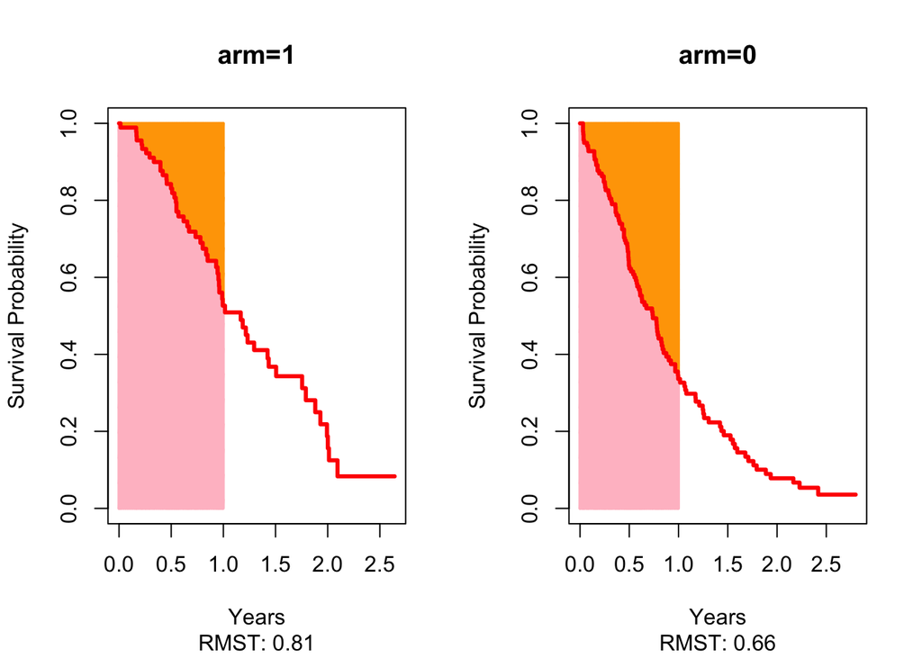

```r
# Plot survival curves and shaded RMST regions
### however the curves had minimal customization described in the help
plot(a, xlab = "Years", ylab = "Survival Probability", density = 60)
```

```r
# OPTIONAL: RMST comparison with covariate adjustment (e.g., age)
# a_adj <- rmst2(time = lung$years, status = lung$status, arm = lung$sex_binary,
#                tau = 1, covariates = data.frame(age = lung$age))
# print(a_adj)
```

## Male vs Female survival curves

The code below visualizes Kaplan-Meier survival curves for males and females using `ggsurvfit`. It includes shaded confidence intervals and a number-at-risk table, allowing clear comparison of survival probabilities by sex over time.

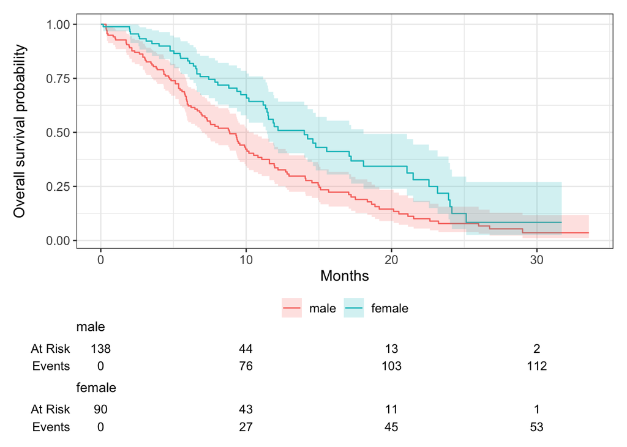

```r
# plot curves with ggplot2-based ggsurvfit, adding shaded confidence intervals
# and a risk table
survfit2(Surv(months, status) ~ sex, data = lung) %>%
  ggsurvfit() +
  labs(
    x = "Months",
    y = "Overall survival probability"
  ) +
  add_confidence_interval() +
  add_risktable()
```

## Test for difference between males and females

The code below uses the log-rank test (`survdiff`) to evaluate whether there is a statistically significant difference in survival between male and female patients. It compares the entire survival curves non-parametrically.

```r
# Test whether survival differs between male and female patients
# 'survdiff' performs a log-rank test comparing survival distributions
survdiff(Surv(months, status) ~ sex, data = lung)
```

```
## Call:
## survdiff(formula = Surv(months, status) ~ sex, data = lung)
##
##              N Observed Expected (O-E)^2/E (O-E)^2/V
## sex=male   138      112     91.6      4.55      10.3
## sex=female  90       53     73.4      5.68      10.3
##
##  Chisq= 10.3  on 1 degrees of freedom, p= 0.001
```

## Examine complementary log-log plot

The code below creates a complementary log-log plot to assess the proportional hazards assumption between sexes. Parallel lines in the transformed scale (log(-log(S(t))) vs log(time)) suggest that the hazard ratio is constant over time.

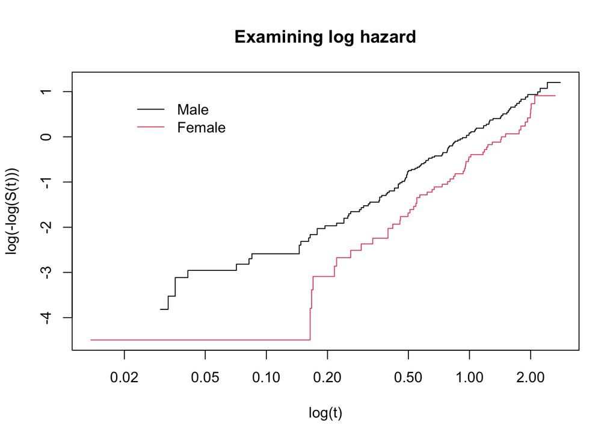

```r
# Create a complementary log-log plot to assess proportional hazards assumption
# 'fun="cloglog"' transforms survival curves to a log(-log(S(t))) vs. log(time) scale
# This helps evaluate if hazard ratios are constant over time (i.e., parallel lines)
plot(lung.survgrp, fun = "cloglog", col = 1:2,
     xlab = "log(t)", ylab = "log(-log(S(t)))",
     main = "Examining log hazard")

# Add legend to distinguish curves by sex
legend(.02, 1, c("Male", "Female"), col = 1:2, lty = 1, bty = "n")
```

## Examine risktable ECOG score

The code below simplifies the ECOG performance score by collapsing higher values into a single category. It then plots Kaplan-Meier curves by ECOG group using `ggsurvfit`, adding shaded confidence intervals and a number-at-risk table for interpretability.

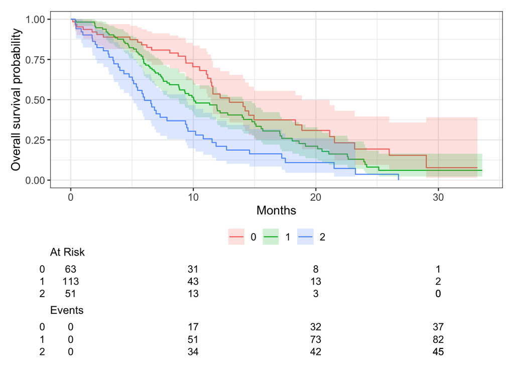

```r
# Simplify ECOG performance score by collapsing values >2 into a single group
# (coded as 2)
lung$myph.ecog <- ifelse(lung$ph.ecog > 2, 2, lung$ph.ecog)

# Fit Kaplan-Meier survival curves by simplified ECOG group
survfit2(Surv(months, status) ~ myph.ecog, data = lung) %>%
  ggsurvfit() +
  labs(
    x = "Months",
    y = "Overall survival probability"
    ) +
  add_confidence_interval() +
  add_risktable()
```

## Examine complementary log-log plot ECOG score

The code below plots Kaplan-Meier curves and complementary log-log transformations for simplified ECOG groups. It visually assesses whether the proportional hazards assumption holds by checking for whether the transformed plots are parallel.

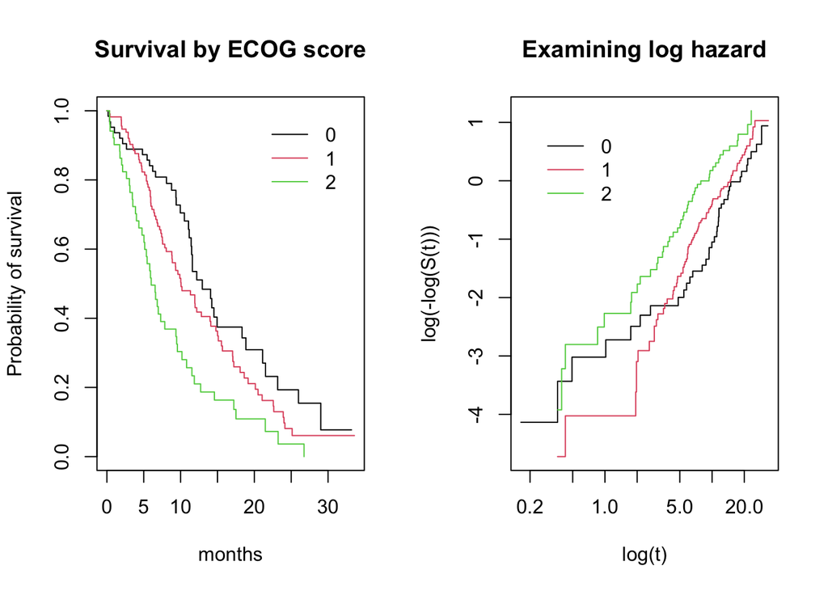

```r
# Collapse ECOG scores >2 into a single category to simplify comparison
lung$myph.ecog <- ifelse(lung$ph.ecog > 2, 2, lung$ph.ecog)

# Set up side-by-side plotting
par(mfrow = c(1, 2))

# Plot standard Kaplan-Meier survival curves by ECOG score
# Allows visual comparison of survival probability over time
plot(survfit(Surv(months, status) ~ myph.ecog, data = lung),
     col = 1:3, xlab = "months", ylab = "Probability of survival",
     main = "Survival by ECOG score")
legend(20, 1, c("0", "1", "2"), col = 1:3, lty = 1, bty = "n")

# Plot complementary log-log transformed survival curves
# Used to assess proportional hazards assumption visually (look for roughly parallel lines)
plot(survfit(Surv(months, status) ~ myph.ecog, data = lung),
     fun = "cloglog", col = 1:3, xlab = "log(t)", ylab = "log(-log(S(t)))",
     main = "Examining log hazard")
legend(.2, 1, c("0", "1", "2"), col = 1:3, lty = 1, bty = "n")
```

## Test for difference between ECOG groups

The code below uses a log-rank test (`survdiff`) to assess whether survival differs significantly across ECOG performance status groups. It tests for overall differences in survival curves among the categories.

```r
# Perform a log-rank test to assess whether survival differs by ECOG score
survdiff(Surv(months, status) ~ myph.ecog, data = lung)
```

```
## Call:
## survdiff(formula = Surv(months, status) ~ myph.ecog, data = lung)
##
## n=227, 1 observation deleted due to missingness.
##
##               N Observed Expected (O-E)^2/E (O-E)^2/V
## myph.ecog=0  63       37     54.2    5.4331    8.2119
## myph.ecog=1 113       82     83.5    0.0279    0.0573
## myph.ecog=2  51       45     26.3   13.2582   15.9641
##
##  Chisq= 19  on 2 degrees of freedom, p= 8e-05
```

## Peto-Peto example

The code below compares survival between treatment groups in the `ovarian` dataset. It plots Kaplan-Meier curves with risk tables and performs survival tests using two weighting schemes: standard log-rank (rho = 0) and Peto-Peto (rho = 1), which emphasizes early differences.

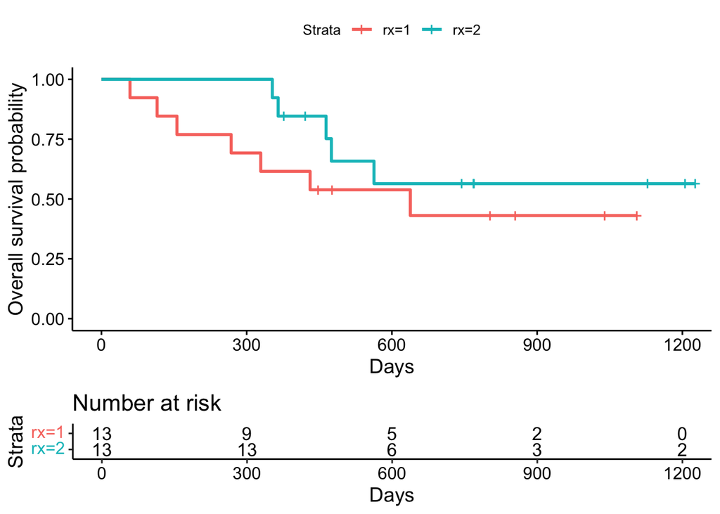

```r
# Fit survival curves for ovarian cancer data by treatment group
# Use log-log confidence intervals (more accurate at tail ends)
ocafit <- survfit(Surv(futime, fustat) ~ rx, data = ovarian, conf.type = "log-log")

# Plot survival curves with risk table using 'survminer'
library(survminer)
ggsurvplot(ocafit, xlab = "Days", ylab = "Overall survival probability",
           main = "Ovarian cancer survival by treatment", risk.table = TRUE)
```

```r
# Run survival tests using different weights:
# rho = 1 → Peto-Peto test (more weight on early differences)
# rho = 0 → standard log-rank test
survdiff(Surv(futime, fustat) ~ rx, data = ovarian, rho = 1)
```

```
## Call:
## survdiff(formula = Surv(futime, fustat) ~ rx, data = ovarian,
##     rho = 1)
##
##       N Observed Expected (O-E)^2/E (O-E)^2/V
## rx=1 13     5.89     4.12     0.761      1.68
## rx=2 13     3.50     5.27     0.595      1.68
##
##  Chisq= 1.7  on 1 degrees of freedom, p= 0.2
```

```r
survdiff(Surv(futime, fustat) ~ rx, data = ovarian, rho = 0)
```

```
## Call:
## survdiff(formula = Surv(futime, fustat) ~ rx, data = ovarian,
##     rho = 0)
##
##       N Observed Expected (O-E)^2/E (O-E)^2/V
## rx=1 13        7     5.23     0.596      1.06
## rx=2 13        5     6.77     0.461      1.06
##
##  Chisq= 1.1  on 1 degrees of freedom, p= 0.3
```

## Multivariable Cox example

The code below fits a multivariable Cox proportional hazards model using the `lung` dataset. It includes predictors such as sex, age, ECOG score, and Karnofsky performance score, providing hazard ratios and confidence intervals for each covariate.

```r
# Fit a multivariable Cox proportional hazards model
# Predictors: sex, age, ECOG score, Karnofsky performance score
fitmv <- coxph(Surv(time, status) ~ sex + age + ph.ecog + ph.karno, data = lung)
summary(fitmv)
```

```
## Call:
## coxph(formula = Surv(time, status) ~ sex + age + ph.ecog + ph.karno,
##     data = lung)
##
##   n= 226, number of events= 163
##    (2 observations deleted due to missingness)
##
##                coef exp(coef)  se(coef)      z Pr(>|z|)
## sexfemale -0.572802  0.563943  0.169222 -3.385 0.000712 ***
## age        0.012868  1.012951  0.009404  1.368 0.171226
## ph.ecog    0.633077  1.883397  0.176034  3.596 0.000323 ***
## ph.karno   0.012558  1.012637  0.009514  1.320 0.186842
## ---
## Signif. codes:  0 '***' 0.001 '**' 0.01 '*' 0.05 '.' 0.1 ' ' 1
##
##           exp(coef) exp(-coef) lower .95 upper .95
## sexfemale    0.5639     1.7732    0.4048    0.7857
## age          1.0130     0.9872    0.9945    1.0318
## ph.ecog      1.8834     0.5310    1.3338    2.6594
## ph.karno     1.0126     0.9875    0.9939    1.0317
##
## Concordance= 0.632  (se = 0.025 )
## Likelihood ratio test= 31.27  on 4 df,   p=3e-06
## Wald test            = 30.61  on 4 df,   p=4e-06
## Score (logrank) test = 31.06  on 4 df,   p=3e-06
```

## Cox vs log-rank

The code below compares two approaches for estimating an unadjusted difference in survival between groups (1) a Cox proportional hazards model estimating hazard ratios, and (2) a log-rank test comparing survival distributions between sexes. Note the test using the score statistic from (1) is the same as the log-rank test statistic

```r
# Cox model: tests association of sex with survival, adjusting for time
fit <- coxph(Surv(time, status) ~ sex, data = lung)
summary(fit)
```

```
## Call:
## coxph(formula = Surv(time, status) ~ sex, data = lung)
##
##   n= 228, number of events= 165
##
##              coef exp(coef) se(coef)      z Pr(>|z|)
## sexfemale -0.5310    0.5880   0.1672 -3.176  0.00149 **
## ---
## Signif. codes:  0 '***' 0.001 '**' 0.01 '*' 0.05 '.' 0.1 ' ' 1
##
##           exp(coef) exp(-coef) lower .95 upper .95
## sexfemale     0.588      1.701    0.4237     0.816
##
## Concordance= 0.579  (se = 0.021 )
## Likelihood ratio test= 10.63  on 1 df,   p=0.001
## Wald test            = 10.09  on 1 df,   p=0.001
## Score (logrank) test = 10.33  on 1 df,   p=0.001
```

```r
# Log-rank test: compares survival distributions between sexes non-parametrically
survdiff(Surv(months, status) ~ sex, data = lung)
```

```
## Call:
## survdiff(formula = Surv(months, status) ~ sex, data = lung)
##
##              N Observed Expected (O-E)^2/E (O-E)^2/V
## sex=male   138      112     91.6      4.55      10.3
## sex=female  90       53     73.4      5.68      10.3
##
##  Chisq= 10.3  on 1 degrees of freedom, p= 0.001
```

## Testing proportional hazards

The code below tests the proportional hazards (PH) assumption for the multivariable Cox model using `cox.zph`. It checks whether the effect of each covariate is constant over time, both graphically and by using a score test for each variable interacted with time (Default is the linear term time). See survival package for more details.

```r
# Test proportional hazards assumption for the multivariable model
# Each covariate tested for time-varying effects
temp <- cox.zph(fitmv)
print(temp)
```

```
##           chisq df    p
## sex      1.7133  1 0.19
## age      0.0668  1 0.80
## ph.ecog  1.6902  1 0.19
## ph.karno 5.4535  1 0.02
## GLOBAL   7.3678  4 0.12
```

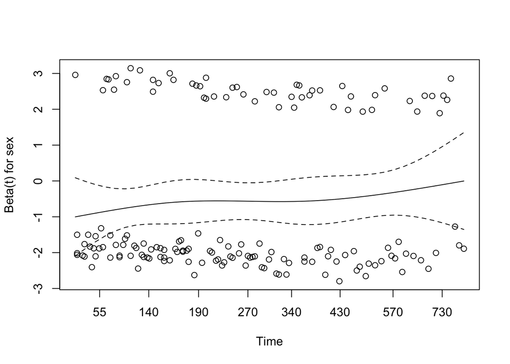

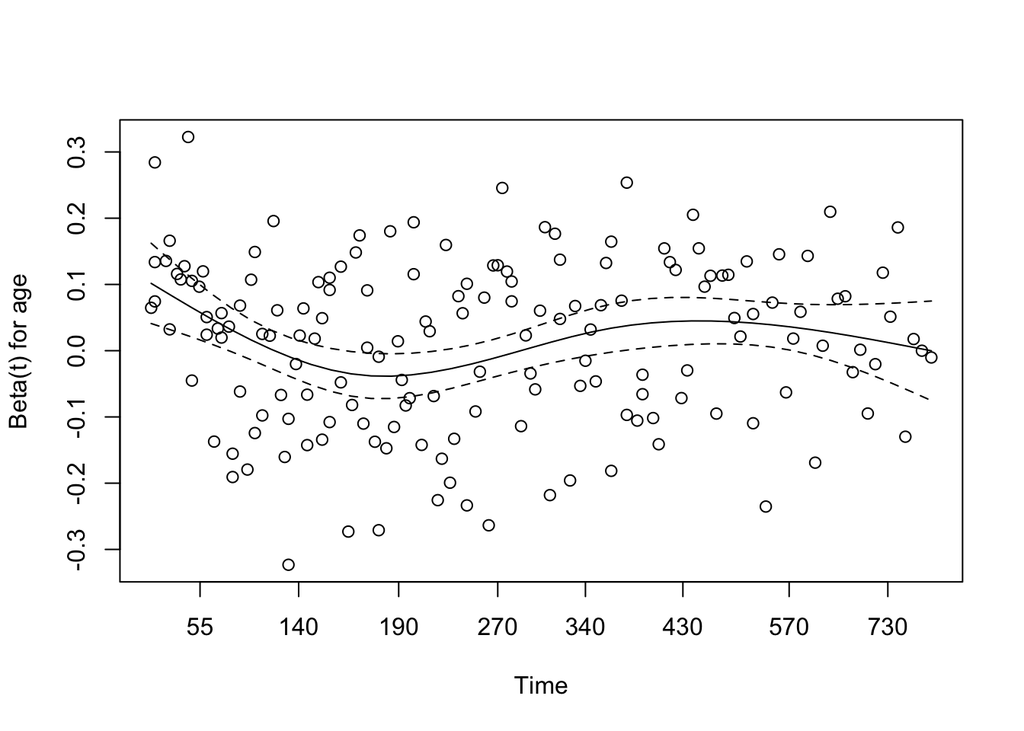

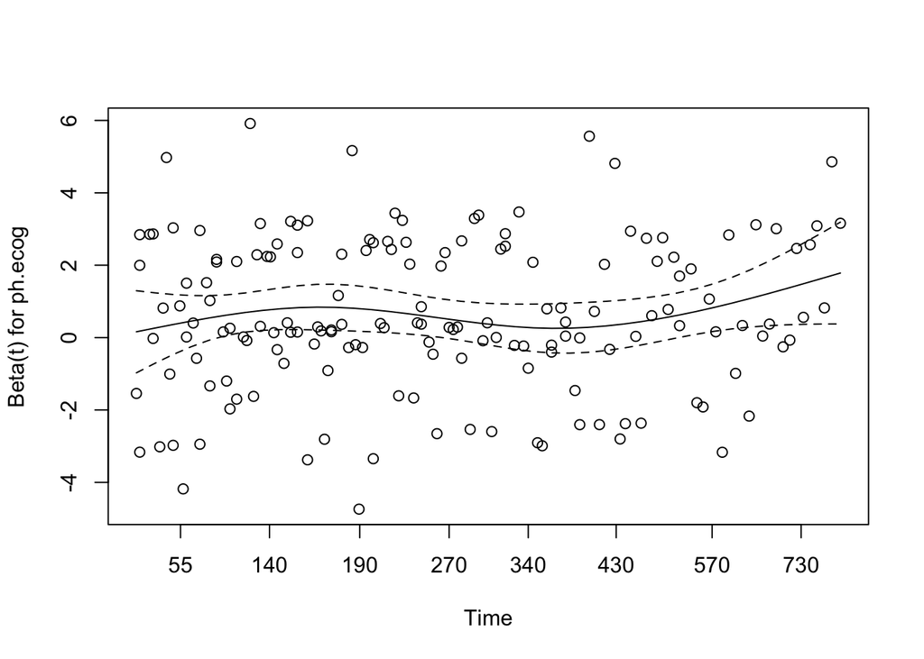

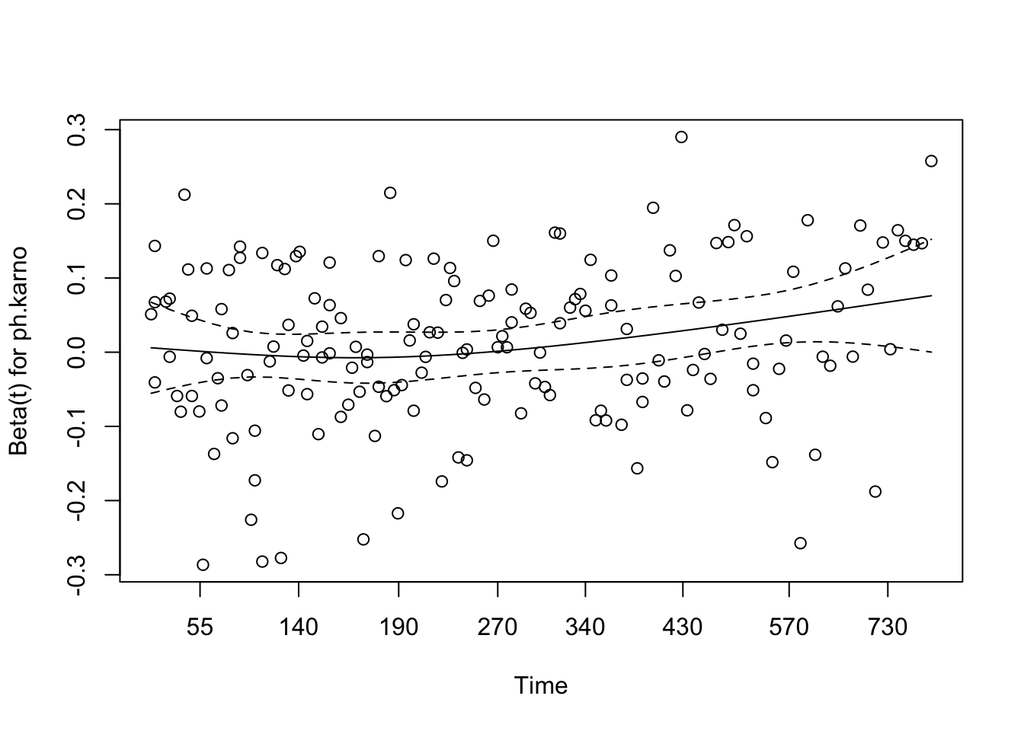

```r
plot(temp)
```

## Univariable testing proportional hazards

The code below tests the proportional hazards assumption for a single covariate (sex) using `cox.zph`. It fits a univariable Cox model and checks for time- dependent effects with the score test, as described above, and plots of the estimated change in the coefficient over time.

```r
# Fit Cox model for a single variable (sex) and test PH assumption
fit <- coxph(Surv(time, status) ~ sex, data = lung)
temp <- cox.zph(fit)
print(temp)
```

```
##        chisq df     p
## sex     2.86  1 0.091
## GLOBAL  2.86  1 0.091
```

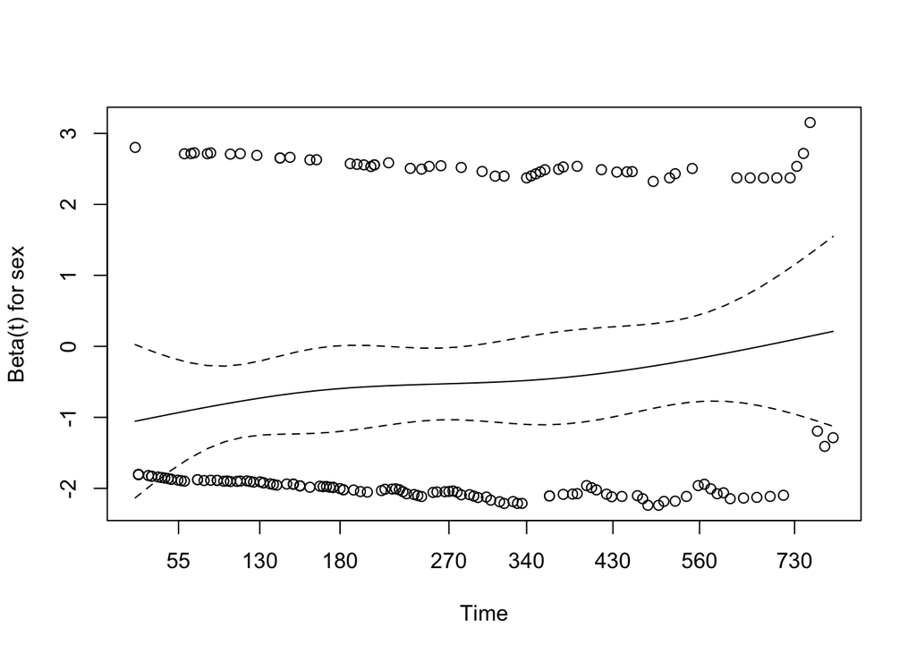

```r
plot(temp)
```

## ECOG - time-varying coefficient?

The code below fits a multivariable Cox model including ECOG score and checks whether its effect violates the proportional hazards assumption. The `cox.zph` function and beta(t) plots help detect time-varying effects.

```r
# Fit multivariable Cox model without stratification
# Used here to assess whether ECOG might violate the PH assumption
fitmvStrat <- coxph(Surv(time, status) ~ sex + age + ph.karno + ph.ecog, data = lung)
summary(fitmvStrat)
```

```
## Call:
## coxph(formula = Surv(time, status) ~ sex + age + ph.karno + ph.ecog,
##     data = lung)
##
##   n= 226, number of events= 163
##    (2 observations deleted due to missingness)
##
##                coef exp(coef)  se(coef)      z Pr(>|z|)
## sexfemale -0.572802  0.563943  0.169222 -3.385 0.000712 ***
## age        0.012868  1.012951  0.009404  1.368 0.171226
## ph.karno   0.012558  1.012637  0.009514  1.320 0.186842
## ph.ecog    0.633077  1.883397  0.176034  3.596 0.000323 ***
## ---
## Signif. codes:  0 '***' 0.001 '**' 0.01 '*' 0.05 '.' 0.1 ' ' 1
##
##           exp(coef) exp(-coef) lower .95 upper .95
## sexfemale    0.5639     1.7732    0.4048    0.7857
## age          1.0130     0.9872    0.9945    1.0318
## ph.karno     1.0126     0.9875    0.9939    1.0317
## ph.ecog      1.8834     0.5310    1.3338    2.6594
##
## Concordance= 0.632  (se = 0.025 )
## Likelihood ratio test= 31.27  on 4 df,   p=3e-06
## Wald test            = 30.61  on 4 df,   p=4e-06
## Score (logrank) test = 31.06  on 4 df,   p=3e-06
```

```r
# Examine proportional hazards assumption
temp <- cox.zph(fitmvStrat)
print(temp)
```

```
##           chisq df    p
## sex      1.7133  1 0.19
## age      0.0668  1 0.80
## ph.karno 5.4535  1 0.02
## ph.ecog  1.6902  1 0.19
## GLOBAL   7.3678  4 0.12
```

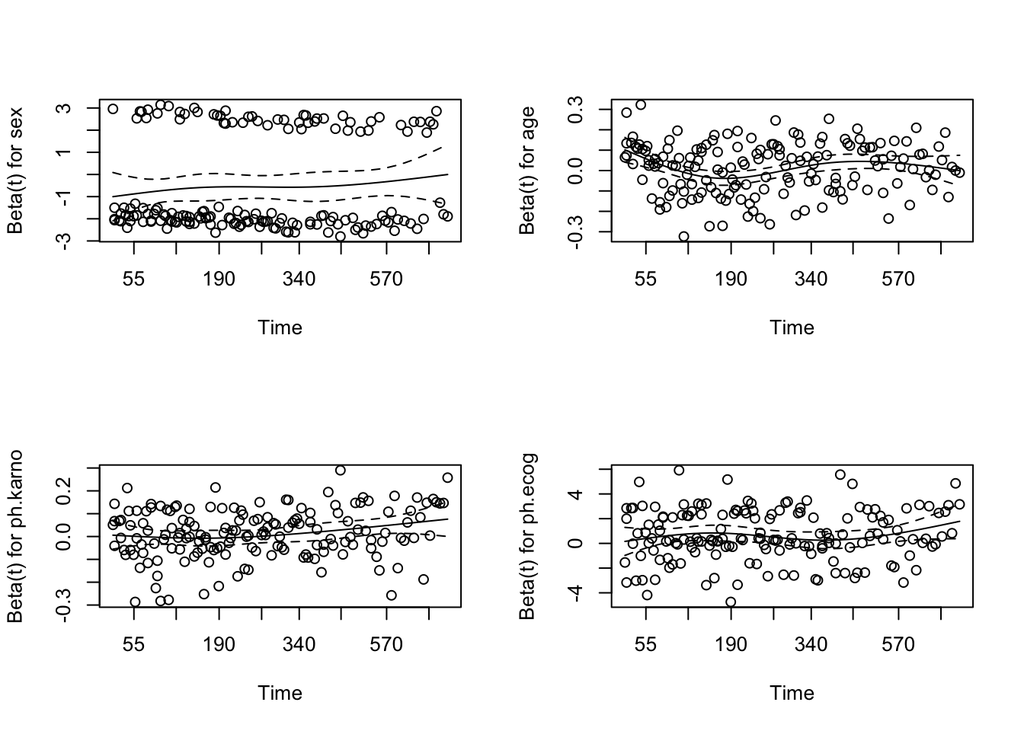

```r
par(mfrow = c(2, 2))
plot(temp)
```

## Stratified Cox model

The code below fits a stratified Cox model to handle a potential violation of the proportional hazards assumption for ECOG. By stratifying on ECOG, the model allows separate baseline hazard functions across ECOG groups, improving model validity. PH assumptions are reassessed post-stratification.

```r
# Fit stratified Cox model to account for potential PH violation in ECOG
# Stratifies by ph.ecog so that baseline hazard differs across strata
fitmvStrat <- coxph(Surv(time, status) ~ sex + age + ph.karno + strata(ph.ecog),
                    data = lung)
summary(fitmvStrat)
```

```
## Call:
## coxph(formula = Surv(time, status) ~ sex + age + ph.karno + strata(ph.ecog),
##     data = lung)
##
##   n= 226, number of events= 163
##    (2 observations deleted due to missingness)
##
##                coef exp(coef)  se(coef)      z Pr(>|z|)
## sexfemale -0.573231  0.563701  0.173027 -3.313 0.000923 ***
## age        0.012419  1.012496  0.009387  1.323 0.185864
## ph.karno   0.011162  1.011224  0.009680  1.153 0.248889
## ---
## Signif. codes:  0 '***' 0.001 '**' 0.01 '*' 0.05 '.' 0.1 ' ' 1
##
##           exp(coef) exp(-coef) lower .95 upper .95
## sexfemale    0.5637     1.7740    0.4016    0.7913
## age          1.0125     0.9877    0.9940    1.0313
## ph.karno     1.0112     0.9889    0.9922    1.0306
##
## Concordance= 0.58  (se = 0.026 )
## Likelihood ratio test= 13.54  on 3 df,   p=0.004
## Wald test            = 12.94  on 3 df,   p=0.005
## Score (logrank) test = 13.22  on 3 df,   p=0.004
```

```r
# Check PH assumption again (should now be improved for ECOG)
temp <- cox.zph(fitmvStrat)
print(temp)
```

```
##           chisq df    p
## sex      1.6872  1 0.19
## age      0.0927  1 0.76
## ph.karno 3.2727  1 0.07
## GLOBAL   4.5945  3 0.20
```

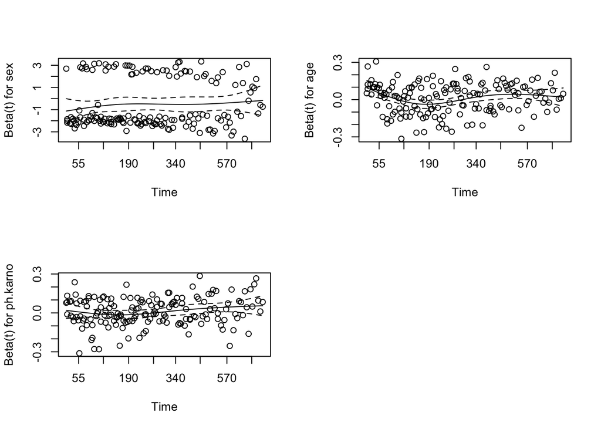

```r
par(mfrow = c(2, 2))
plot(temp)
```

## Relationships between variables

The code below explores relationships between key variables to check for potential confounding or imbalances. It summarizes ECOG scores by sex and age distributions across ECOG groups.

```r
# Explore potential confounding or imbalance between ECOG and sex
tapply(lung$myph.ecog, lung$sex, summary)
```

```
## $male
##    Min. 1st Qu.  Median    Mean 3rd Qu.    Max.    NA's
##  0.0000  0.0000  1.0000  0.9562  1.0000  2.0000       1
##
## $female
##    Min. 1st Qu.  Median    Mean 3rd Qu.    Max.
##  0.0000  0.0000  1.0000  0.9333  1.0000  2.0000
```

```r
# Explore how age differs across ECOG groups
tapply(lung$age, lung$myph.ecog, summary)
```

```
## $`0`
##    Min. 1st Qu.  Median    Mean 3rd Qu.    Max.
##   39.00   56.50   61.00   61.16   68.00   82.00
##
## $`1`
##    Min. 1st Qu.  Median    Mean 3rd Qu.    Max.
##   40.00   55.00   63.00   61.45   68.00   80.00
##
## $`2`
##    Min. 1st Qu.  Median    Mean 3rd Qu.    Max.
##   48.00   60.50   68.00   66.29   73.00   77.00
```